# Dutch Blitz Project Report

Olivia Martin

2022-12-07

**Introduction.** The purpose of this experiment was to determine what factors impact a player’s score in the game Dutch Blitz, as well as the importance of each factor. I identified four potential explanatory variables, covering the starting conditions, ending conditions, and duration of each game, and players.

The rules of Dutch Blitz can be found at https://www.youtube.com/watch?v=6n3VyC0ngY8&t=74s. The rules for this experiment deviated in the following ways: no Post Pile stacking was allowed, and the number of cards remaining in the Blitz Pile was not factored into the score. In this context, a game refers to one round of play rather than as many rounds as necessary to reach 75 points.

**Data Collection.** The data used in this experiment was collected from 30 games of Dutch Blitz. They were played by four subjects, whose names have been coded by the color of the deck they played with: red buggies, yellow buckets, blue plows, and green buckets. Games were played on November 29th, 2022, in two sets of 15 games each.

**Variables.**

- `ID`: game ID. Each game created four cases, one for each player’s spread and score. This variable exists for data management purposes and is not for use in models.
- `time`: duration of the game in seconds.
- `blitz`: color alias of player that ended the game by emptying their Blitz Pile.
- `player`: the color alias of the player to whom each case’s spread and score belongs.
- `spread`: the sum of the values of the four exposed cards in each player’s Post and Blitz Piles at the start of the game. If a player’s spread was below five or above 25, the player replaced one of the cards with a card from the Wood Pile until the spread fell within the target range.
- `score`: the total number of cards played by each player in the game.

**Exploration of Data.**

```r
blitz_data = read.csv("blitz_data.csv")
player_order = c('red', 'yellow', 'green', 'blue')

blitz_display = blitz_data %>% mutate(player = ordered(blitz_data$player, levels = player_order), blitz = ordered(blitz_data$blitz, levels = player_order))
```

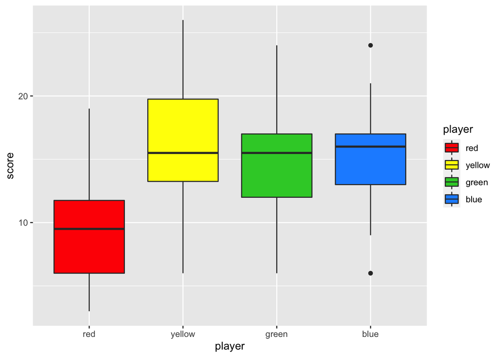

```r
player_colors = c('red', 'yellow', 'limegreen', 'dodgerblue')
blitz_display %>% ggplot(aes(x = player, y = score, fill = player)) +
  geom_boxplot() +
  scale_fill_manual(values = player_colors)
```

As we see here, Yellow generally scored the highest and Red the lowest. This trend is supported by the results of many games of Blitz, though based on past games I would have expected Green to fall more firmly between Blue and Red.

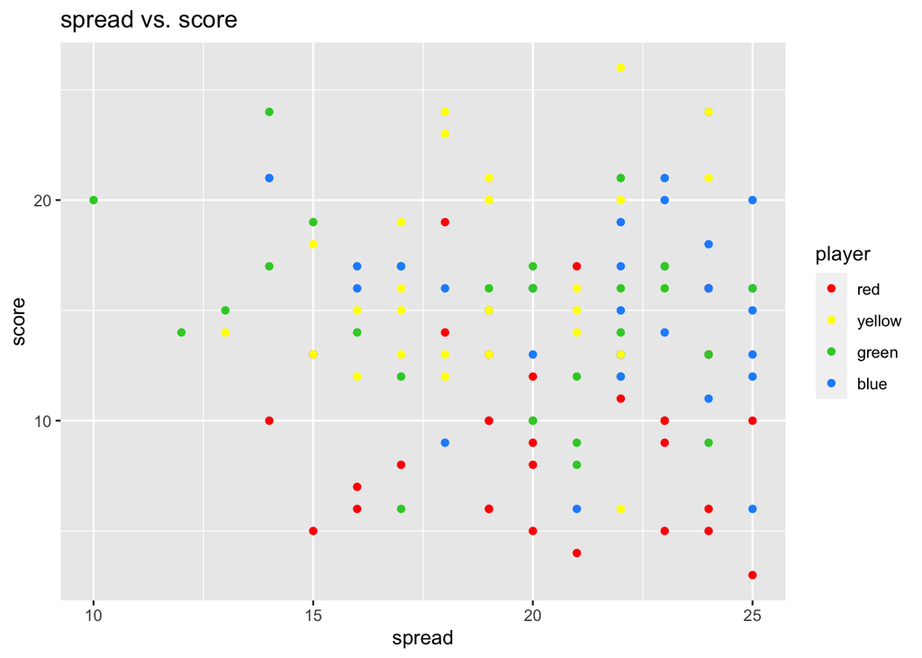

```r
ggplot(blitz_display, aes(x = spread, y = score, color = player)) +
  geom_point() +
  scale_color_manual(values = player_colors) +
  labs(title = 'spread vs. score')
```

At first, I assumed spread would have a strong impact on score because a lower spread ostensibly means a player has more playable cards early in the game. However, even when sorted by player, spread appears to be a very weak predictor of score, and may not be useful at all.

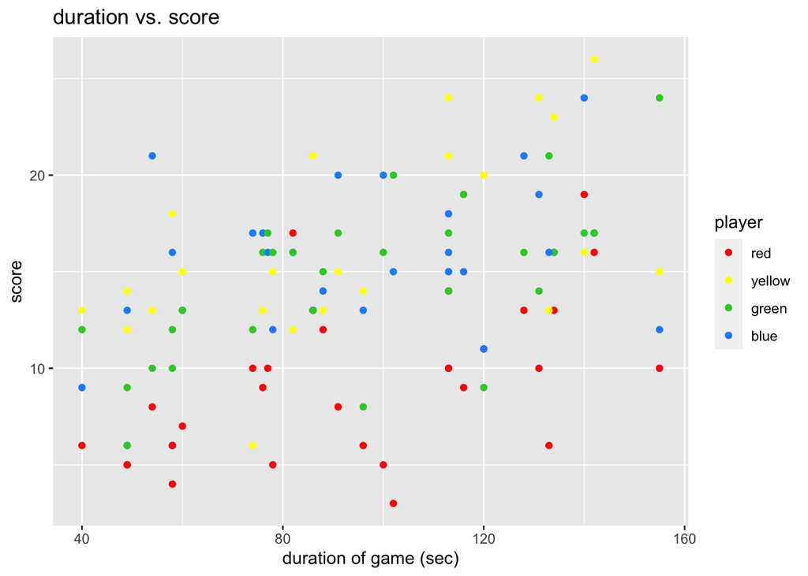

```r
ggplot(blitz_display, aes(x = time, y = score, color = player)) +
  geom_point() +
  scale_color_manual(values = player_colors) +
  labs(title = 'duration vs. score', x = 'duration of game (sec)')
```

Duration, as expected, does seem to have some effect on score when sorted by player. The relationship also seems to be somewhat linear.

**Exploration of Models.** In pursuit of the best model, I examined the individual impact of each of the potential explanatory variables. Here are the results:

[output not shown]

Based on this information, I would discount `blitz` and `spread` as explanatory variables. `blitz` does appear to have a tiny impact on `score`, but based on the p-value I cannot conclude that this result is repeatable; I suspect the impact is more to do with random chance.* `player` and `time`, and perhaps an interaction term between the two, will offer the best model given the available data.

*See Limitations for further notes on this subject.

| Model Formula | Parameters | R<sup>2</sup> | p-value |
| --- | --- | --- | --- |
| `score` ~ `player + time` | 5 | 0.50 | <10<sup>-4</sup> |
| `score` ~ `player * time` | 8 | 0.50 | <10<sup>-4</sup> |
| `score` ~ `player:time` | 5 | 0.47 | <10<sup>-4</sup> |
| `score` ~ `player + player:time` | 8 | 0.50 | <10<sup>-4</sup> |
| `score` ~ `time + player:time` | 5 | 0.47 | <10<sup>-4</sup> |

These calculations suggest that the interaction between player and time is not particularly significant, and the ANOVA table gives `player:time` a p-value of 0.86. Player and time seem to be the predominant factors in determining score, though the effect of the duration does not appear to vary by player.

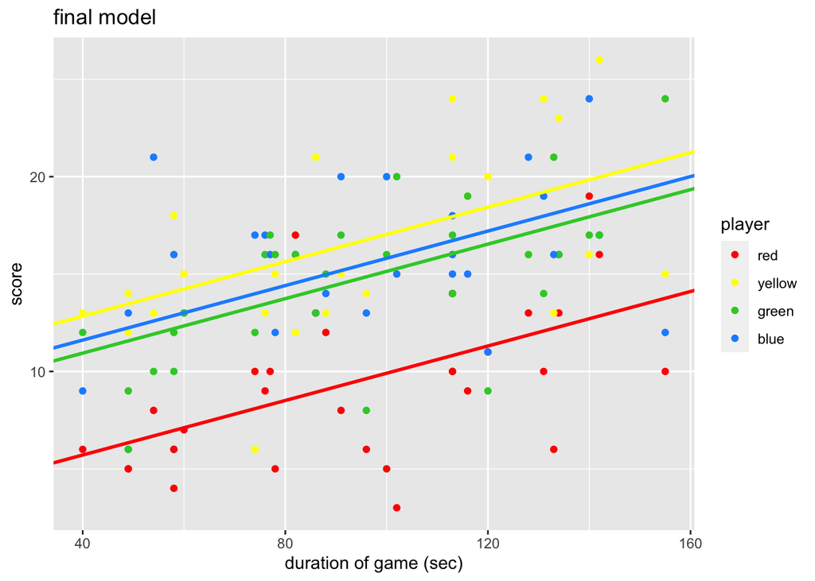

```r
ggplot(blitz_display, aes(x = time, y = score, color = player)) +
  geom_point() +
  geom_abline(slope = 0.07, intercept = 2.91, size = 1, color = 'red', ) +
  geom_abline(slope = 0.07, intercept = 10.04, size = 1, color = 'yellow') +
  geom_abline(slope = 0.07, intercept = 8.14, size = 1, color = 'limegreen') +
  geom_abline(slope = 0.07, intercept = 8.81, size = 1, color = 'dodgerblue') +
  scale_color_manual(values = player_colors) +
  labs(title = 'final model', x = 'duration of game (sec)')
```

**Limitations.**

- Number of players would likely also affect score (as well as time), but was not studied here.
- There were some games wherein a certain color of card could not be played until well into the game; for example, in game 4, no red ones were played until second 61, making any red cards in the Blitz, Post, or Wood Piles ineffective. Further exploration or control of this variable might yield more specific results. For purposes of this report, such variation is considered an aspect of random chance.
- According to official Dutch Blitz rules, the score is the number of cards played minus twice the number of cards remaining in the Blitz Pile at the end of play. This group does not adhere to that rule. Were it followed, I conjecture that `blitz` would be a useful explanatory variable.
- According to official Dutch Blitz rules, Post Piles can be stacked under certain conditions. This group does not adhere to that rule, and introducing it for data collection would likely have warped the outcome. However, a more thorough study on this topic would likely need to incorporate that rule, and I suspect it would affect the outcome.
- Players are comfortable with each other; results might vary depending on opponents.

**Appendix.** Below are the summaries for various models I looked into. Not all were considered potential “best” models; some were examined for context or sheer folly.

```r
summary(lm(score ~ player, blitz_data))
```

```
##
## Call:
## lm(formula = score ~ player, data = blitz_data)
##
## Residuals:
##      Min       1Q   Median       3Q      Max
## -10.4667  -2.7083  -0.2833   2.4667   9.6667
##
## Coefficients:
##              Estimate Std. Error t value Pr(>|t|)
## (Intercept)   15.2333     0.7552  20.170  < 2e-16 ***
## playergreen   -0.7000     1.0681  -0.655    0.514
## playerred     -5.9000     1.0681  -5.524 2.06e-07 ***
## playeryellow   1.2333     1.0681   1.155    0.251
## ---
## Signif. codes:  0 '***' 0.001 '**' 0.01 '*' 0.05 '.' 0.1 ' ' 1
##
## Residual standard error: 4.137 on 116 degrees of freedom
## Multiple R-squared:  0.3092, Adjusted R-squared:  0.2914
## F-statistic: 17.31 on 3 and 116 DF,  p-value: 2.35e-09
```

```r
summary(lm(score ~ blitz, blitz_data))
```

```
##
## Call:
## lm(formula = score ~ blitz, data = blitz_data)
##
## Residuals:
##      Min       1Q   Median       3Q      Max
## -11.8125  -2.9219   0.2167   2.3500  11.2167
##
## Coefficients:
##             Estimate Std. Error t value Pr(>|t|)
## (Intercept)  14.8125     0.8547  17.330   <2e-16 ***
## blitzgreen   -0.0125     1.3782  -0.009   0.9928
## blitzred      1.4375     1.9112   0.752   0.4535
## blitzyellow  -2.0292     1.0584  -1.917   0.0577 .
## ---
## Signif. codes:  0 '***' 0.001 '**' 0.01 '*' 0.05 '.' 0.1 ' ' 1
##
## Residual standard error: 4.835 on 116 degrees of freedom
## Multiple R-squared:  0.05632,    Adjusted R-squared:  0.03191
## F-statistic: 2.308 on 3 and 116 DF,  p-value: 0.08021
```

```r
summary(lm(score ~ spread, blitz_data))
```

```
##
## Call:
## lm(formula = score ~ spread, data = blitz_data)
##
## Residuals:
##      Min       1Q   Median       3Q      Max
## -10.3428  -3.3985   0.2672   2.6572  12.3234
##
## Coefficients:
##             Estimate Std. Error t value Pr(>|t|)
## (Intercept)  16.1241     2.6902   5.994 2.29e-08 ***
## spread       -0.1113     0.1322  -0.842    0.402
## ---
## Signif. codes:  0 '***' 0.001 '**' 0.01 '*' 0.05 '.' 0.1 ' ' 1
##
## Residual standard error: 4.92 on 118 degrees of freedom
## Multiple R-squared:  0.005967,   Adjusted R-squared:  -0.002457
## F-statistic: 0.7084 on 1 and 118 DF,  p-value: 0.4017
```

```r
summary(lm(score ~ time, blitz_data))
```

```
##
## Call:
## lm(formula = score ~ time, data = blitz_data)
##
## Residuals:
##      Min       1Q   Median       3Q      Max
## -11.3505  -3.1066  -0.0712   3.2858   9.8884
##
## Coefficients:
##             Estimate Std. Error t value Pr(>|t|)
## (Intercept)  7.46776    1.28781   5.799 5.70e-08 ***
## time         0.06748    0.01284   5.256 6.65e-07 ***
## ---
## Signif. codes:  0 '***' 0.001 '**' 0.01 '*' 0.05 '.' 0.1 ' ' 1
##
## Residual standard error: 4.442 on 118 degrees of freedom
## Multiple R-squared:  0.1897, Adjusted R-squared:  0.1828
## F-statistic: 27.62 on 1 and 118 DF,  p-value: 6.646e-07
```

```r
summary(lm(score ~ player + time, blitz_data))
```

```
##
## Call:
## lm(formula = score ~ player + time, data = blitz_data)
##
## Residuals:
##     Min      1Q  Median      3Q     Max
## -9.0361 -1.8700 -0.3702  2.4249  8.5574
##
## Coefficients:
##              Estimate Std. Error t value Pr(>|t|)
## (Intercept)   8.80943    1.16847   7.539 1.19e-11 ***
## playergreen  -0.70000    0.91363  -0.766    0.445
## playerred    -5.90000    0.91363  -6.458 2.64e-09 ***
## playeryellow  1.23333    0.91363   1.350    0.180
## time          0.06748    0.01023   6.598 1.33e-09 ***
## ---
## Signif. codes:  0 '***' 0.001 '**' 0.01 '*' 0.05 '.' 0.1 ' ' 1
##
## Residual standard error: 3.538 on 115 degrees of freedom
## Multiple R-squared:  0.4989, Adjusted R-squared:  0.4815
## F-statistic: 28.63 on 4 and 115 DF,  p-value: < 2.2e-16
```

```r
summary(lm(score ~ player * time, blitz_data))
```

```
##
## Call:
## lm(formula = score ~ player * time, data = blitz_data)
##
## Residuals:
##     Min      1Q  Median      3Q     Max
## -8.9768 -1.8899 -0.2855  2.5836  8.5356
##
## Coefficients:
##                   Estimate Std. Error t value Pr(>|t|)
## (Intercept)       10.03988    2.07209   4.845 4.09e-06 ***
## playergreen       -3.05147    2.93037  -1.041  0.29997
## playerred         -6.97330    2.93037  -2.380  0.01902 *
## playeryellow      -0.26369    2.93037  -0.090  0.92846
## time               0.05455    0.02066   2.641  0.00945 **
## playergreen:time   0.02470    0.02922   0.845  0.39966
## playerred:time     0.01127    0.02922   0.386  0.70030
## playeryellow:time  0.01573    0.02922   0.538  0.59148
## ---
## Signif. codes:  0 '***' 0.001 '**' 0.01 '*' 0.05 '.' 0.1 ' ' 1
##
## Residual standard error: 3.574 on 112 degrees of freedom
## Multiple R-squared:  0.5022, Adjusted R-squared:  0.4711
## F-statistic: 16.14 on 7 and 112 DF,  p-value: 1.541e-14
```

```r
summary(lm(score ~ player:time, blitz_data))
```

```
##
## Call:
## lm(formula = score ~ player:time, data = blitz_data)
##
## Residuals:
##     Min      1Q  Median      3Q     Max
## -8.2848 -1.9290 -0.2528  2.5192  9.2721
##
## Coefficients:
##                   Estimate Std. Error t value Pr(>|t|)
## (Intercept)        7.46776    1.05544   7.075 1.25e-10 ***
## playerblue:time    0.07889    0.01199   6.582 1.44e-09 ***
## playergreen:time   0.07472    0.01199   6.234 7.75e-09 ***
## playerred:time     0.02418    0.01199   2.017    0.046 *
## playeryellow:time  0.09212    0.01199   7.686 5.58e-12 ***
## ---
## Signif. codes:  0 '***' 0.001 '**' 0.01 '*' 0.05 '.' 0.1 ' ' 1
##
## Residual standard error: 3.641 on 115 degrees of freedom
## Multiple R-squared:  0.4696, Adjusted R-squared:  0.4511
## F-statistic: 25.45 on 4 and 115 DF,  p-value: 4.11e-15
```

```r
summary(lm(score ~ player + player:time, blitz_data))
```

```
##
## Call:
## lm(formula = score ~ player + player:time, data = blitz_data)
##
## Residuals:
##     Min      1Q  Median      3Q     Max
## -8.9768 -1.8899 -0.2855  2.5836  8.5356
##
## Coefficients:
##                   Estimate Std. Error t value Pr(>|t|)
## (Intercept)       10.03988    2.07209   4.845 4.09e-06 ***
## playergreen       -3.05147    2.93037  -1.041 0.299968
## playerred         -6.97330    2.93037  -2.380 0.019019 *
## playeryellow      -0.26369    2.93037  -0.090 0.928460
## playerblue:time    0.05455    0.02066   2.641 0.009454 **
## playergreen:time   0.07925    0.02066   3.836 0.000207 ***
## playerred:time     0.06583    0.02066   3.186 0.001866 **
## playeryellow:time  0.07028    0.02066   3.402 0.000929 ***
## ---
## Signif. codes:  0 '***' 0.001 '**' 0.01 '*' 0.05 '.' 0.1 ' ' 1
##
## Residual standard error: 3.574 on 112 degrees of freedom
## Multiple R-squared:  0.5022, Adjusted R-squared:  0.4711
## F-statistic: 16.14 on 7 and 112 DF,  p-value: 1.541e-14
```

```r
summary(lm(score ~ time + player:time, blitz_data))
```

```
##
## Call:
## lm(formula = score ~ time + player:time, data = blitz_data)
##
## Residuals:
##     Min      1Q  Median      3Q     Max
## -8.2848 -1.9290 -0.2528  2.5192  9.2721
##
## Coefficients:
##                    Estimate Std. Error t value Pr(>|t|)
## (Intercept)        7.467763   1.055443   7.075 1.25e-10 ***
## time               0.078892   0.011986   6.582 1.44e-09 ***
## time:playergreen  -0.004175   0.009372  -0.445    0.657
## time:playerred    -0.054712   0.009372  -5.838 4.99e-08 ***
## time:playeryellow  0.013230   0.009372   1.412    0.161
## ---
## Signif. codes:  0 '***' 0.001 '**' 0.01 '*' 0.05 '.' 0.1 ' ' 1
##
## Residual standard error: 3.641 on 115 degrees of freedom
## Multiple R-squared:  0.4696, Adjusted R-squared:  0.4511
## F-statistic: 25.45 on 4 and 115 DF,  p-value: 4.11e-15
```

```r
anova(lm(score ~ player * time, blitz_data))
```

|  | Df | Sum Sq | Mean Sq | F value | Pr(>F) |
| --- | --- | --- | --- | --- | --- |
| player | 3 | 888.625000 | 296.208333 | 23.1923758 | 9.460998e-12 |
| time | 1 | 545.060128 | 545.060128 | 42.6768524 | 1.971884e-09 |
| player:time | 3 | 9.465188 | 3.155063 | 0.2470336 | 8.632969e-01 |
| Residuals | 112 | 1430.441350 | 12.771798 | NA | NA |